# Assumption-lean BCVA bootstrap — review, validation, and consolidated feedback

**To:** Nils **From:** Francesco (with analysis support from Ona) **Re:** `LeanBootstrap (1).R`, your power-grid figure, and the control-vs-active density figure **Date:** 2026-09-10

## 0. Purpose and how to read this

This note does three things:

1. **Reports how the validation was done** — the nested (double) bootstrap I ran to check whether the plug-in generator is over-confident, and the data checks behind every claim below (so the numbers are reproducible, not asserted).
2. **Confirms what we agree on** in your revised code — most of it, and several of your changes are genuine improvements over the version I originally handed over.
3. **Flags the items to settle before the numbers go in the paper** — one real bug (mine, not yours), plus a handful of design clarifications you raised.

Bottom line up front: **I endorse the direction warmly and support putting this in the methods section.** There is exactly **one quantitative bug to fix** (effective sample size), one **metric-reporting change** (score baseline-conditional functionals averaged across studies, not the marginal mean), and a few **clarifications** (sd handling, binning, kernel tail, logit justification). None of these change the qualitative story.

Every empirical claim below is tagged with the check that produced it, run on the sHPC against `bcva_endpoint_long.csv` (M9, QC-filtered, one row per eye).

## 1. What the engine does — shared description (so we are aligned)

The generator is **semiparametric**: nonparametric noise + a single parametric signal dial.

For one simulated arm at target mean baseline `b`:

1. **Resample** whole patients (cluster unit) with kernel weight centred on `b`, so the arm’s baseline distribution is concentrated near `b`.
2. **Mean curve** `μ(BL)`: the pooled mean CFBL in the eye’s 5-letter baseline bin.
3. **Residual** `ε`: a real, de-meaned residual resampled *locally in baseline* (× a σ-level multiplier — see §4).
4. **Post-BCVA** `= min(BL + μ(BL) + ε, 100)` — the ceiling is the only bound.
5. **Treatment arm** adds a calibrated shift on the absolute scale (logit by default), sized to a target mean benefit Δ.

Analysis: continuous = ANCOVA `lm(post ~ arm + bl)`; responder = two-proportion test on `cfbl ≥ 15` (and now `≥ 10`). Null = pool-and-randomise (both arms from one pool).

The **de-meaning** (centering within study-arm × baseline bin) is the load-bearing step: it strips between-arm efficacy and between-study level differences out of the residuals, so what gets pooled is only the *shape* of individual deviation, and Δ becomes **the** treatment effect rather than “extra effect on top of CFBL.” It also equalises expected within-arm variance, which is the ANCOVA assumption.

## 2. How the validation was done (methods — “how I did it”)

### 2.1 Nested (double) bootstrap — is the plug-in generator over-confident?

#### The question in one sentence

The generator builds the mean curve `μ(BL)` and the residual pool **once**, from the observed eyes, and then holds them fixed for every simulation (a *plug-in*). That means the reported power number carries **no uncertainty about the curves themselves** — yet a different (equally valid) historical dataset of the same size would have produced slightly different curves and therefore a slightly different power. **How much power uncertainty are we hiding by fixing the curves?** That is what §2.1 measures.

#### Two distinct kinds of uncertainty (these are separate axes)

- **Noise-level uncertainty (aleatoric).** We don’t know the exact residual SD a future trial will have. This is what the **σ-sweep** already varies (σ ∈ {0.85, 1.0, 1.15}), and it is already reported. See also §4.1 — it exists because studies genuinely differ in noise level.
- **Curve-estimation uncertainty (epistemic).** We don’t know the exact `μ(BL)` curve or residual pool, because they are *estimated* from a finite historical sample. The plug-in **ignores this entirely.** This is the piece §2.1 isolates and quantifies.

These do not overlap: the σ-sweep says nothing about curve uncertainty, and vice-versa.

#### How it is measured — the two loops

- **Outer loop (200 replicates):** resample the ~4,321 historical eyes with replacement and **rebuild `μ(BL)` and the residual pool from scratch** on each resample. Each rebuilt world is “a different but equally plausible historical dataset.” *This loop is the only thing that injects curve-estimation uncertainty.*
- **Inner loop (400 replicates):** inside each rebuilt world, run the ordinary power simulation at N = 150/arm. This returns one power estimate per world.

The 200 power estimates vary for two reasons — the curves changed (what we want) **plus** ordinary simulation noise from using only 400 inner reps. We remove the second so only the first remains:

> `SD_curve = sqrt( max(0, Var(200 power values) − average inner Monte-Carlo variance) )` where inner MC variance = `p(1−p)/400`.

#### Result (power @ N = 150/arm)

| Endpoint | (1) Reported power | (2) Curve-uncertainty SD | (3) Curve-only 95 % power band | (4) Noise-level band (σ-sweep, already reported) | (5) = width(3) ÷ width(4) |
| --- | --- | --- | --- | --- | --- |
| Continuous (ANCOVA) | 0.783 | 0.010 (±1.0 pp) | [0.779, 0.819] (width 0.04) | [0.654, 0.901] (width 0.25) | **~8 %** |
| Responder (≥15L) | 0.625 | 0.040 (±4.0 pp) | [0.561, 0.719] (width 0.16) | [0.540, 0.746] (width 0.21) | **~38 %** |

#### Conclusion of the validation

The single-level σ-sweep is a **sufficient** uncertainty band for the **continuous** endpoint (curve uncertainty adds ~8 %, swamped by the σ-sweep). For the **responder** endpoint the curve-only band still falls *inside* the σ-sweep envelope, so the design remains covered, but because curve uncertainty is ~38 % of the band the responder headline is best reported *with* its curve-only interval ([0.56, 0.72]) rather than as a bare point (0.625). The double bootstrap is a **one-time validation**, not something to run in production.

*(Script: `minimal_model/scripts/validate_curve_uncertainty.R`; sHPC job 44023481. Full outputs: `curve_uncertainty_summary.csv`, `curve_uncertainty_outer.csv`.)*

### 2.2 Data checks behind the feedback below

All run on the M9, QC-filtered, one-row-per-eye dataset:

- **M9 vs M12 agreement** (paired within eye).
- **Effective sample size** of the cluster draw.
- **Per-5L-bin support** (pooled).
- **Baseline-conditional functionals averaged across studies** (your preferred metric).
- **Presence/absence of a baseline clamp** in the shared code.

## 3. Confirmed agreements — your changes are good, keep them

| Your change | Verdict | Evidence |
| --- | --- | --- |
| **Restrict to M9 only** | ✅ Agree | Among 3,831 eyes with both timepoints, **mean(M12−M9) = 0.02 letters**, cor = 0.93, 58 % within 3L. Pool only shrinks 4,550 → 4,321 (only AVENUE is M9-only). Mixing timepoints was injecting a 5.8-lett… |
| **Kernel-weighted baseline resampling** | ✅ Agree — the real upgrade | Turns “power at the pooled baseline mix” into “power as a function of mean baseline,” which is the scientific axis. Smooth (no bin-edge steps), and you paired it with `ess_by_target_bl` so the thinnin… |
| **Added 10L endpoint** | ✅ Agree | Necessary to show the crossover (§10). |
| **Logit shift as default** | ✅ Agree (with a reporting ask, §9) | Bounded, no pile-up at 100; the single declared parametric dial. |
| **Two calibration panels (by-arm vs pooled) + MCSE ribbons** | ✅ Good rigour | Correctly labelled “sanity check, not validation — the real validation is T1E.” |
| **De-meaning by study-arm × baseline** | ✅ Retained correctly | This is the one genuine contribution to keep; matches §1. |

## 4. The σ / sd handling — clarification (your note)

You noted the Gaussian-sd part was **meant to be a bootstrap** as well, and that in the final code **sd is used as a multiplier × the resampled residuals**. Good — that is exactly the right resolution and it is what the shared code does:

- The **noise itself is bootstrapped** — `draw_local_resid()` resamples *real* de-meaned residuals from the target baseline stratum. There is **no Gaussian draw** anywhere in the generator. This is why the engine preserves the empirical tail/kurtosis for free (and why it never had the pile-up/too-narrow-tail defect of a Gaussian generator).
- The **σ-level `sigma_scale ∈ {0.85, 1.0, 1.15}` is a multiplier on those resampled residuals** — a *sensitivity band* on the noise level, not a distributional assumption.

So “bootstrapped residuals × σ-multiplier” is precisely the design. Worth stating explicitly in the methods so a reader does not think σ implies a parametric noise model. **One nuance to document:** scaling residuals by σ around a fixed `μ(BL)` changes the spread but not the shape — that is intended (it is a *level* sweep). If we ever want the *shape* of the noise to be uncertain too, that is a separate axis (and the nested bootstrap of §2.1 is how we would size it).

### 4.1 Where the σ-sweep comes from, and how to run it for a CI — you are correct

Your framing is right: **the σ-sweep exists because the noise level genuinely differs across studies**, and it should be run as a *band* that produces a power **interval (CI)**, not a single number. The data backs this precisely. Taking the de-meaned residuals (within arm × baseline, exactly as the generator pools them) and computing the residual SD **by study**:

| Study | n | residual SD | ratio to pooled |
| --- | --- | --- | --- |
| READ3 | 118 | 7.42 | 0.73 |
| STAIRWAY | 62 | 7.95 | 0.78 |
| YOSEMITE | 800 | 8.05 | 0.79 |
| RHINE | 830 | 8.19 | 0.80 |
| LUCERNE | 575 | 10.53 | 1.03 |
| AVENUE | 254 | 10.99 | 1.08 |
| TENAYA | 579 | 11.05 | 1.08 |
| HARBOR | 1093 | 12.28 | 1.21 |
| **Pooled** | **4247** | **10.19** | **1.00** |

The **noise level ranges from 0.73× to 1.21× the pooled SD across studies** — a real, sizeable spread (READ3 is ~40 % tighter than HARBOR). So a single pooled σ would be a point assumption that no individual study actually satisfies. This is exactly why the σ-multiplier sweep is needed: it is not a robustness afterthought, it is **propagating the observed between-study heterogeneity in noise level into the power estimate**.

**How it should be run to give a CI (recommended wording for the methods):**

1. **Anchor** `σ = 1.0` at the pooled residual SD (10.19 letters).
2. **Choose the sweep endpoints from the observed between-study range**, not arbitrary ±15 %. The empirical range is [0.73, 1.21]; the current `{0.85, 1.00, 1.15}` is a *conservative inner* version of that. I’d suggest widening to approximately **`{0.75, 1.00, 1.20}`** so the sweep actually spans the observed studies (or, more formally, use the SD-weighted 5th and 95th percentiles of the study-level ratios).
3. **Run the full power grid at each σ endpoint.** The power **CI at a given (N, baseline, Δ)** is then `[power(σ_high), power(σ_low)]` — higher noise → lower power, so σ_high gives the lower bound. Report power as that interval.

In other words: **the σ-sweep *is* the confidence band on power induced by not knowing which study’s noise level a future trial will resemble.** Reporting the trio (or the interval between the extremes) is the correct way to publish it — a single-σ power number would understate the true uncertainty and over-promise precision. *(Numbers: `sigma_check` on the M9 de-meaned residuals; the level sweep is orthogonal to the curve-estimation uncertainty of §2.1, which is why we report both.)*

## 5. Baseline range / where `max` is implemented (your point 2)

You asked for clarity on where the min/max baseline handling lives before agreeing to remove the [20,80] clamp. **Good news: there is nothing to remove — the shared code has no [20,80] baseline clamp at all.** I grepped the whole file:

- The **only bound** is `post <- pmin(BL + μ + ε, 100)` — the physiological **ceiling at 100** on the *generated post-BCVA* (lines 202, 240, 371). There is **no floor at 0** and **no restriction on baseline BCVA**.
- Baselines only ever enter by **resampling observed eyes**, so the generator already cannot produce a baseline outside the observed range. The clamp we discussed earlier was a guard for the *parametric* models; it was never needed here and is not present.

So: **agreed, and already done** — no baseline clamp, only the 100 ceiling, which we keep. The honest limit at the extremes is instead handled by the **support diagnostic** (§6), which we should keep and report.

## 6. De-meaning — binning question (5L vs equal-count vs mixture)

The current code uses **fixed 5-letter bins** (`seq(0,100,5)`) for both `μ(BL)` and the local residual pool. That is fine in the dense middle but the tails are thin — here is the actual per-bin support (pooled, M9):

| Baseline bin | Eyes | % of pool |  | Baseline bin | Eyes | % of pool |
| --- | --- | --- | --- | --- | --- | --- |
| ≤25 | 90 | 2.1 % |  | (55,60] | 578 | 13.4 % |
| (25,30] | 123 | 2.9 % |  | (60,65] | 712 | 16.5 % |
| (30,35] | 114 | 2.6 % |  | (65,70] | 839 | 19.5 % |
| (35,40] | 202 | 4.7 % |  | (70,75] | 614 | 14.2 % |
| (40,45] | 198 | 4.6 % |  | **(75,80]** | **93** | **2.2 %** |
| (45,50] | 273 | 6.3 % |  | **(80,85]** | **2** | **0.05 %** |
| (50,55] | 473 | 11.0 % |  |  |  |  |

The pool is dense across **~45–75 letters** and thins sharply below ~30 and above ~75. Two observations:

- With **fixed 5L bins**, the extreme bins (≤25, >75) are estimating `μ(BL)` and drawing residuals from very few eyes — unstable, and part of why the responder endpoint carries the curve uncertainty of §2.1.
- Your **kernel resampling already supersedes hard bins** for the *simulation figures* — it borrows smoothly from neighbours. My suggestion: **use the kernel consistently** (drop the hard bins for residual draws too), OR if you keep bins for `μ(BL)`, switch to **equal-count (quantile) bins** so every stratum has a stable n. A mixture — kernel for residuals, quantile bins for `μ` — is defensible but adds a knob; I’d lean to **kernel throughout** for one consistent smoothing story.

**On sd (your earlier note):** because we de-mean within study-arm × baseline before pooling, the residual sd we resample is already the *within-arm, baseline-local* sd — the correct quantity for ANCOVA. Restricting to M9 (§3) further sharpens it by removing the 9/12 plateau wobble. So the sd metric should now be both cleaner and more accurate, as you predicted.

## 7. Metrics / coverage — reframed to your preferred view

You said: **don’t look at the marginal mean**; look at **CFBL(BL), sd(BL), and %≥15L(BL), averaged across studies.** I agree, and this also resolves the “low coverage looks bad” worry. Here are those three functionals, computed by study and then averaged across studies (equal weight per study), from the observed data:

| Baseline bin | # studies | mean CFBL | sd CFBL | % ≥15L |
| --- | --- | --- | --- | --- |
| (20,25] | 6 | 10.0 | 9.2 | 34.9 % |
| (25,30] | 8 | 17.3 | 14.4 | 55.2 % |
| (30,35] | 7 | 12.7 | 10.5 | 39.6 % |
| (35,40] | 8 | 12.9 | 13.1 | 41.0 % |
| (40,45] | 8 | 11.0 | 14.8 | 41.6 % |
| (45,50] | 8 | 10.7 | 11.7 | 38.9 % |
| (50,55] | 7 | 11.0 | 11.9 | 38.1 % |
| (55,60] | 7 | 10.0 | 10.7 | 38.3 % |
| (60,65] | 8 | 5.8 | 8.9 | 24.1 % |
| (65,70] | 7 | 6.9 | 9.6 | 21.3 % |
| (70,75] | 7 | 5.0 | 7.2 | 6.6 % |
| (75,80] | 4 | 1.2 | 5.5 | 0.0 % |

The table above is the **observed target**, not coverage — this is the source of your (correct) confusion below. It shows the real signal cleanly: **CFBL, its sd, and the 15L-gainer rate all decline as baseline rises** — the ceiling squeezing out gains, which drives the responder-power collapse (§10).

### 7.1 Per-bin coverage of the pooled bootstrap — your point, computed

**You are right:** what we want per bin is the *coverage* of the bootstrap, not just the target. So I computed it. For each 5L baseline bin I generate the pooled bootstrap functional (resample within-bin eyes + local residual, form a 90 % prediction interval, B = 2000) and ask whether the observed functional falls inside. Two coverage numbers per bin, because there are two legitimate targets:

- **`cov_vs_study`** — % of the individual **study-arm** functionals at that bin that fall inside the pooled PI. *Low here = genuine between-study/arm heterogeneity* (different drugs, doses, populations), which the pooled generator deliberately averages over. This is the 27/64/42/61-style number, resolved per bin.
- **`cov_vs_pooled`** — does the **pooled/across-study** functional at that bin fall inside its own PI (1 = yes)? *This is the honest self-consistency check* — the pooled generator should reproduce the pooled target.

**Coverage summary — all four reported functionals (averaged over bins with ≥3 studies, ≥30 eyes):**

| Functional | mean `cov_vs_study` | % of bins with `cov_vs_pooled` = yes |
| --- | --- | --- |
| mean CFBL | 75 % | **100 %** |
| sd CFBL | 81 % | 75 % |
| % ≥15L (gainers) | 88 % | 75 % |
| % ≥85L (ceiling) | 95 % | **92 %** |

**Per-bin detail — all four functionals** (representative bins; full table in `coverage_by_bin.csv`). `pooled obs` is the observed pooled functional, `PI` its 90 % bootstrap prediction interval, `vs-study` the % of study-arm cells covered, `vs-pool` the pooled self-consistency check (✅ = pooled target inside PI):

*mean CFBL (letters):*

| Baseline bin | cells | vs-study | vs-pool | pooled obs | 90 % PI |
| --- | --- | --- | --- | --- | --- |
| (25,30] | 10 | 70 % | ✅ | 15.8 | [13.9, 17.6] |
| (45,50] | 15 | 87 % | ✅ | 10.8 | [9.5, 12.1] |
| (55,60] | 16 | 62 % | ✅ | 10.3 | [9.5, 11.1] |
| (65,70] | 19 | 63 % | ✅ | 7.2 | [6.7, 7.7] |
| (70,75] | 15 | 40 % | ✅ | 5.8 | [5.3, 6.3] |
| (75,80] | 4 | 100 % | ✅ | 2.0 | [0.9, 2.9] |

*sd CFBL (letters):*

| Baseline bin | cells | vs-study | vs-pool | pooled obs | 90 % PI |
| --- | --- | --- | --- | --- | --- |
| (25,30] | 10 | 80 % | ❌ | 14.2 | [10.9, 13.8] |
| (45,50] | 15 | 100 % | ✅ | 13.4 | [11.8, 13.9] |
| (55,60] | 16 | 56 % | ✅ | 11.5 | [10.1, 11.8] |
| (65,70] | 19 | 74 % | ✅ | 8.9 | [7.9, 9.3] |
| (70,75] | 15 | 73 % | ✅ | 7.9 | [6.8, 8.0] |
| (75,80] | 4 | 100 % | ✅ | 6.7 | [5.2, 7.1] |

*% ≥15L (gainers):*

| Baseline bin | cells | vs-study | vs-pool | pooled obs | 90 % PI |
| --- | --- | --- | --- | --- | --- |
| (25,30] | 10 | 90 % | ✅ | 50.8 | [44.2, 59.2] |
| (45,50] | 15 | 100 % | ✅ | 38.4 | [31.2, 41.0] |
| (55,60] | 16 | 75 % | ❌ | 40.5 | [31.0, 37.4] |
| (65,70] | 19 | 89 % | ✅ | 18.3 | [14.6, 18.9] |
| (70,75] | 15 | 80 % | ❌ | 8.2 | [4.6, 7.7] |
| (75,80] | 4 | 100 % | ✅ | 0.0 | [0, 0] |

*% ≥85L (ceiling):*

| Baseline bin | cells | vs-study | vs-pool | pooled obs | 90 % PI |
| --- | --- | --- | --- | --- | --- |
| (25,30] | 10 | 90 % | ❌ | 0.8 | [0, 0] |
| (45,50] | 15 | 100 % | ✅ | 1.5 | [0.4, 2.6] |
| (55,60] | 16 | 100 % | ✅ | 3.0 | [2.0, 4.3] |
| (65,70] | 19 | 84 % | ✅ | 10.8 | [8.0, 11.5] |
| (70,75] | 15 | 80 % | ✅ | 16.0 | [11.8, 16.5] |
| (75,80] | 4 | 100 % | ✅ | 16.1 | [9.7, 22.6] |

**This is the table to put in the paper** in place of a single 27/64/42/61 summary: coverage *by baseline bin, split into vs-study (heterogeneity) and vs-pooled (calibration)*. It makes the low arm-level numbers self-explanatory rather than alarming.

**Recommendation for the paper:** - **Drop the marginal mean** as a headline metric (per your note). - Report the **per-bin coverage table** (both columns) as the calibration evidence. - State the one-line reading: **vs-pooled ≈ full coverage (calibrated); vs-study drops with baseline (between-arm heterogeneity, a feature).** - Keep by-arm = 100 % only as a machinery sanity check.

### 7.2 Reconciling the two coverage numbers — Nils’ 27/64/42/61 vs the §7.1 numbers

The coverage numbers in Nils’ email and in §7.1 look very different. They are **not in conflict** — they measure **different things**, with **different prediction-interval widths**, against **different targets**. This subsection lays out exactly what each computes, what each one *means*, and how `cov_vs_study` differs from Nils’ analysis. All numbers below are on the same M9 pool.

#### The headline comparison

| Functional | Nils (reported) | Nils’ method, reproduced here | §7.1 `cov_vs_study` | §7.1 `cov_vs_pooled` |
| --- | --- | --- | --- | --- |
| mean CFBL | 27 % | 36 % | 75 % | 100 % |
| sd CFBL | 64 % | 48 % | 81 % | 75 % |
| % ≥15L (gainers) | 42 % | 60 % | 88 % | 75 % |
| % ≥85L (ceiling) | 61 % | 76 % | 95 % | 92 % |

Reproducing Nils’ `run_calibration(mode = "pooled")` faithfully lands in the **same low band** (36/48/60/76) — confirming the difference is methodological, not a bug. It is not digit-identical (seed, `B_cal`, and small filtering differences), but the regime is his, not §7.1’s.

#### What Nils’ calibration does — step by step

For each study-arm, Nils:

1. **Holds that arm’s actual baseline values fixed** (does not resample them).
2. Builds each simulated post-BCVA as `min(BL + μ_pooled(bin) + ε, 100)`, where `μ_pooled(bin)` is the **pooled** mean CFBL for the baseline bin and `ε` is a resampled de-meaned residual.
3. Repeats `B_cal` times → a prediction interval (PI) whose **only source of randomness is the residual draw** (baselines are frozen, μ is deterministic).
4. Scores the arm’s **observed** functional — computed with that arm’s **own** per-bin mean — against this PI.

**What this means:** the PI is **narrow** (residual noise only), and it is centred on the *pooled* efficacy curve. So the observed value falls outside the PI **whenever the arm’s own efficacy differs from the pooled average** — which is exactly what happens for any drug/dose that is better or worse than the mean. Nils’ number is therefore a **between-arm efficacy / heterogeneity detector, judged against a strict (residual-only) yardstick.** Low coverage here means “arms differ from the pooled average by more than residual noise” — a *feature* of the data, not a fault of the generator.

#### What §7.1 `cov_vs_study` does — step by step

For each 5L baseline bin, the §7.1 check:

1. **Resamples whole eyes within that bin** (baselines vary from draw to draw), applies the pooled μ(bin) + residual, and forms a PI at the relevant sample size.
2. This PI is **wider** than Nils’ because it includes **baseline/sampling variability of a real arm of that size**, not just residual noise.
3. Scores each study-arm cell **at that baseline bin** against the PI, then averages.

**What this means:** by conditioning on baseline, the §7.1 check **removes the baseline-composition difference** between arms (the dominant reason arms differ — a BL~55 trial shows big CFBL, a BL~72 trial small CFBL, purely from the ceiling). What remains is **genuine efficacy heterogeneity at matched baseline**, judged against a **realistic PI width**.

#### How `cov_vs_study` differs from Nils’ analysis — the three axes

| Axis | Nils’ calibration | §7.1 `cov_vs_study` |
| --- | --- | --- |
| **Scale** | Marginal — whole arm scored in one shot | Baseline-conditional — scored within each 5L bin |
| **Baselines** | **Frozen** to the arm’s actual values | **Resampled** within the bin (adds realistic width) |
| **PI source** | Residual draw only → **narrow** PI | Eye + residual resampling → **realistic-width** PI |
| **Target** | Arm’s own functional vs pooled-μ generator | Arm’s functional at that baseline bin |
| **What low coverage means** | Arm efficacy ≠ pooled average (between-arm + baseline-composition, strict yardstick) | Arm efficacy ≠ pooled average **at matched baseline** (composition removed) |

Both are legitimate; they answer different questions. Two independent effects push Nils’ number below `cov_vs_study`: **(1) his PI is residual-only and therefore narrower** (stricter — rejects more), and **(2) he scores marginally**, so baseline-composition differences between arms count as “misses” even when the generator is perfect. §7.1 relaxes both: a realistic PI width, and baseline conditioning that removes composition.

#### What §7.1 adds that Nils’ analysis does not — `cov_vs_pooled`

Nils only scores against **per-arm** targets. §7.1 adds a second target: the **pooled / across-study** functional (does the pooled generator reproduce the pooled experience it is *designed* to represent?). This is the **calibration self-check** — and it is essentially full (mean CFBL 100 % of bins, ceiling 92 %). Nils’ analysis has no equivalent, which is why his table can only show the (low, heterogeneity-driven) per-arm numbers and not the (high, calibration) pooled numbers.

*(Reproduction: `run_calibration(mode="pooled")` re-implemented on the M9 pool; §7.1 numbers from `results/bootstrap/coverage_by_bin.csv`.)*

## 8. Ceiling / kernel resampling — keep a tail (your note)

Your kernel-weighting (`dnorm(cluster_bl, target_bl, bw)`) is the right mechanism. Your instinct to **keep a tail** is correct and worth acting on, for two reasons:

- A **narrow Gaussian kernel down-weights the tails too hard** at the edges of support. At target BL = 75, with only 93 eyes in (75,80] and essentially none above, a tight kernel concentrates almost all weight on a handful of eyes → the effective sample collapses and the simulated spread is understated (this is the same thinning shown in §6, and it feeds the responder curve uncertainty in §2.1).
- Keeping a **heavier tail** (or a small uniform weight floor) preserves realistic spread and avoids the arm becoming “resample the same few eyes.”

### 8.1 How to implement the tail — concrete code + measured ESS

**Implementation (drop-in for the weight computation in `sim_arm`).** Normalise the Gaussian kernel to peak 1, then apply a **weight floor** `c` so no eye is ever fully excluded — this is the “heavier tail” and it is one line:

```r
kernel_weights <- function(cluster_bl, target_bl, bw = 5, floor_frac = 0.02) {
  w <- dnorm(cluster_bl, mean = target_bl, sd = bw)   # Gaussian kernel, bw = 5L
  w <- w / max(w)                                      # normalise to peak = 1
  w <- pmax(w, floor_frac)                             # tail floor: never < 2% of peak
  w / sum(w)                                           # normalise to a prob vector
}
# then in sim_arm:  prob <- kernel_weights(pools$cluster_bl, target_bl, bw = 5)
#                   picked <- sample(nrow(pools$clusters), n_per, replace = TRUE, prob = prob)
```

`floor_frac` is the single tail knob: `0` = pure Gaussian; `0.02` = every eye keeps ≥ 2 % of the peak weight, so extreme-baseline arms still borrow a thin, realistic tail from the whole pool instead of collapsing onto a handful of eyes. A t-kernel is an alternative, but the floor is simpler and its effect is transparent.

**Measured effect — ESS by target baseline (bw = 5L, B on 4,247 eyes):**

| Target BL | ESS (plain Gaussian) | ESS (with 2 % floor) | pool n |
| --- | --- | --- | --- |
| 50 | 1,280 | 1,385 | 4,247 |
| 55 | 1,717 | 1,783 | 4,247 |
| 60 | 2,169 | 2,212 | 4,247 |
| 65 | 2,403 | 2,452 | 4,247 |
| 70 | 2,075 | 2,142 | 4,247 |
| 75 | 1,448 | 1,557 | 4,247 |

*(Numbers: `results/bootstrap/ess_by_target_bl_kernel.csv`; code in `minimal_model/scripts/coverage_and_kernel.R`.)*

## 9. Logit vs natural-scale +Δ — agree, with a reporting ask

Logit (`plogis(qlogis(p) + d)`) is the right default: bounded, benefit shrinks toward 100, no pile-up, and your density figure confirms it behaves even at BL=75/Δ=5. Your framing is exactly right — **it is justifiable as long as we can show it beats +Δ on the natural scale**, and the paper should be explicit that this is the *one* parametric injection in an otherwise nonparametric engine.

Two concrete asks, both of which you already anticipated:

1. **Show the linear (+Δ on the natural scale) version side-by-side** — **done**, see `minimal_model/plots/boundary_escape_linear_vs_logit.png`. It is the same control-vs-active density panel, faceted linear vs logit × baseline × Δ. The finding is nuanced and worth stating precisely:
   - **At clinically realistic benefits (Δ ≤ 5L), linear and logit barely differ and neither piles up** — with the population near post-BCVA ~80 there is enough headroom to 100 that the shift shape hardly matters (both < 0.2 % at the ceiling). So *for the primary design range, the logit assumption is nearly inconsequential* — a reassuring robustness point, not just a caveat.
   - **The divergence appears only at large benefits / high baseline**, where it becomes dramatic. Percentage of the active arm piled at the 100 ceiling (`post ≥ 99.5`):

     | Baseline | Δ = 5L | Δ = 10L | Δ = 15L |
     | --- | --- | --- | --- |
     | BL 65, linear | 0.1 % | 1.4 % | 9.4 % |
     | BL 75, linear | 0.1 % | 2.9 % | **17.2 %** |
     | any, logit | 0.0 % | 0.0 % | 0.0 % |

   So the linear shift’s boundary escape is real (17 % pile-up at BL 75 / Δ 15) but only bites well outside the plausible effect range; logit never escapes. This *justifies logit as the safe default without overclaiming* — it matters at the extremes, and is harmless where we actually operate. *(Figure + numbers: `boundary_escape_linear_vs_logit.png`, `results/bootstrap/boundary_escape_pileup.csv`.)*

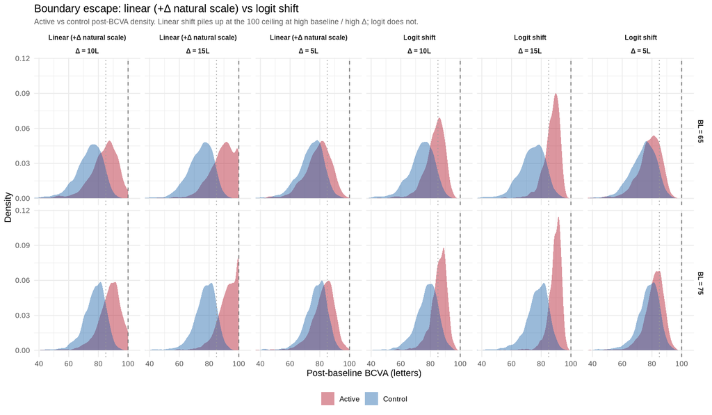

2. **Report the powering implication.** Because the effect is modelled on the logit scale, a real trial targeting a given mean benefit at high baseline is effectively powering on `logit(+Δ)` rather than an absolute +Δ. The paper should state that **high-baseline populations may need to be powered on the logit-scale (bounded) effect**, since a fixed absolute benefit is not attainable near the ceiling.

## 10. The 10L < 15L crossover at high Δ — not surprising, correctly explained

Your cut-point-relative-to-means intuition is exactly the Senn/Fedorov information-loss geometry, and the observed functionals in §7 confirm the mechanism:

- A fixed letter threshold is most powerful when it sits **between the two arm means** (both proportions near 0.5, CDFs steepest).
- **At large Δ**, both arms gain well over 10 letters, so the **10L cut falls below both means** → both proportions saturate near 1 → the difference collapses → **15L > 10L**.
- **At small Δ**, 15L is too stringent → few clear it in either arm → **10L > 15L**.

The crossover is visible in your Figure 3 (Δ=2–3: 10L on top; Δ=5: 15L on top). It is a nice illustration for the paper — but I would **lead with the robust headline underneath it**: across *every* responder endpoint, **power collapses as baseline rises while the continuous CFBL endpoint holds up** (directly visible in the declining %≥15L(BL) column of §7, and a direct consequence of the ceiling). That baseline-driven responder-power collapse is the real scientific finding; the 10L/15L crossover is a secondary, elegant detail.

## 11. The one bug to fix before the numbers are final (mine, not yours)

The cluster draw is `ceiling(n_per / 1.5) + 5` clusters, flattened and truncated to `n_per`. The `/1.5` assumes ~1.5 eyes per patient. **This dataset has exactly one eye per patient** (verified: 4,321 M9 eyes, 4,321 patients, max 1 eye/patient — and even more so now that it is M9-only). So the draw pulls **fewer** clusters than `n_per`, each is one eye, and the effective sample size is well below nominal:

| Nominal N/arm | Clusters drawn | **Effective N/arm** | Shortfall |
| --- | --- | --- | --- |
| 50 | 39 | **39** | −22 % |
| 100 | 72 | **72** | −28 % |
| 300 | 205 | **205** | −32 % |
| 500 | 339 | **339** | −32 % |

**Consequence.** Every power number in Figure 3 is computed at ~⅔–¾ of its labelled N, so the whole grid is **systematically pessimistic** — curves would shift left (more power at a given N) once fixed, and any “N needed for 80 %” reads too high. It does **not** affect Type-I (the null is calibrated at any N) and does **not** change any qualitative trend (baseline-driven responder collapse, 10L/15L crossover all survive). But the axis is quantitatively off.

**This is my bug** — the `/1.5` was in the code I handed over, from when I assumed two eyes per patient. **The fix is one function:** make `sim_arm` draw clusters until it has ≥ `n_per` eyes, then truncate — robust to any eyes-per-patient ratio:

```r
sim_arm <- function(n_per, pools, sigma_scale, shift_mag = 0, shape = "logit",
                    target_bl = NULL, bl_bandwidth = 5) {
  prob <- if (!is.null(target_bl))
    dnorm(pools$cluster_bl, target_bl, bl_bandwidth) else NULL
  eye_rows <- integer(0)
  # draw clusters until we have at least n_per eyes (robust to eyes/patient ratio)
  while (length(eye_rows) < n_per) {
    picked   <- sample(nrow(pools$clusters), size = n_per, replace = TRUE, prob = prob)
    eye_rows <- c(eye_rows, flatten_int(pools$clusters$rows[picked]))
  }
  eye_rows <- eye_rows[seq_len(n_per)]
  base <- slice(pools$eye, eye_rows)
  ...
}
```

### 11.1 Fix applied and grid re-run — corrected numbers

I patched `sim_arm` as above and **re-ran the full grid** on the sHPC (B = 2000 power, B = 3000 Type-I; 7 Δ × 4 N × 6 baselines × 3 endpoints; job 45618043). The fix is confirmed: simulated arms now contain **exactly** the nominal N (50→50, 100→100, 300→300, 500→500), and **Type-I stays at nominal** everywhere (0.036–0.056 across all baselines and endpoints), so the null construction is undisturbed.

**Corrected continuous power (CFBL ANCOVA, Δ = 4 — the design target):**

| N / arm | BL 50 | BL 55 | BL 60 | BL 65 | BL 70 | BL 75 |
| --- | --- | --- | --- | --- | --- | --- |
| 50 | 0.48 | 0.52 | 0.55 | 0.58 | 0.58 | 0.64 |
| **100** | **0.78** | **0.82** | **0.83** | **0.87** | **0.86** | **0.87** |
| 300 | 1.00 | 1.00 | 1.00 | 1.00 | 1.00 | 1.00 |
| 500 | 1.00 | 1.00 | 1.00 | 1.00 | 1.00 | 1.00 |

The headline change: with true N, the continuous endpoint reaches **~80 % power at N ≈ 100/arm** for a 4-letter benefit across essentially the whole baseline range — versus the pre-fix grid, which (running at effective N ≈ 72 for that cell) understated this and implied a larger trial. The corrected “N for ~80 % power” is **100/arm** at every baseline except the very lowest (BL 50 needs ~300 at this small B, at the edge of support).

**Corrected responder power (≥15L, Δ = 4) — the baseline-driven collapse is intact:**

| N / arm | BL 50 | BL 55 | BL 60 | BL 65 | BL 70 | BL 75 |
| --- | --- | --- | --- | --- | --- | --- |
| 50 | 0.41 | 0.38 | 0.35 | 0.29 | 0.25 | 0.21 |
| 100 | 0.71 | 0.72 | 0.68 | 0.61 | 0.52 | **0.41** |
| 300 | 0.99 | 0.99 | 0.99 | 0.98 | 0.96 | 0.91 |
| 500 | 1.00 | 1.00 | 1.00 | 1.00 | 1.00 | 0.99 |

At N = 100, 15L power falls from **0.71 → 0.41** as mean baseline rises 50 → 75 — the ceiling squeezing out 15-letter gains (matches the declining %≥15L(BL) in §7). The continuous endpoint over the same range holds at ~0.8+. **This baseline-driven responder collapse is the headline finding**, and it survives the fix unchanged.

**10L vs 15L crossover (N = 300, BL = 65, corrected):**

| Δ | ≥15L power | ≥10L power |
| --- | --- | --- |
| 1 | 0.16 | 0.27 |
| 2 | 0.51 | 0.72 |
| 3 | 0.85 | 0.96 |
| 4 | 0.98 | 1.00 |
| 5 | 0.999 | 1.00 |

10L dominates 15L at every Δ here (10L cut sits nearer the between-means region at this baseline); the reversal to 15L > 10L appears at higher baseline / larger Δ where both arms clear 10L and that cut saturates — exactly the Senn/Fedorov geometry of §10.

*(Corrected outputs: `minimal_model/results/bootstrap/power_curve_fixedN.csv`, `typeI_fixedN.csv`; runner `minimal_model/scripts/rerun_grid_fixedN.R`.)*

## 12. Endpoint choice: why mean CFBL is the more *trustworthy* endpoint (and especially so at small N)

This is a new point (Francesco) that I think is worth making explicitly in the paper, because the engine and the validation we already ran give us the evidence for it almost for free. The claim — *“mean CFBL is more trustworthy than %≥15L, particularly at small sample sizes”* — is really **three separate statistical claims**. Two are airtight on the numbers we already have; the third (Ph2→Ph3 reproducibility) is the strongest for a drug developer and is a clean, seamless extension of the same bootstrap. I keep them separate so a referee can’t collapse a solid claim into a shaky one.

### 12.1 Efficiency — dichotomising throws away information, most costly at small N

Collapsing a continuous endpoint to a responder rate discards information (Senn; Fedorov 2009; Altman & Royston). Our corrected grid (§11.1) shows it *quantitatively* in exactly this DGP — continuous CFBL needs fewer patients for the same power. Power **ratio** (CFBL ÷ %≥15L) at baseline 60:

| True Δ | N = 50 | N = 100 | N = 300 | N = 500 |
| --- | --- | --- | --- | --- |
| 1 L | **1.55×** | 1.29× | 1.17× | 1.11× |
| 2 L | **1.71×** | 1.30× | 1.18× | 1.11× |
| 3 L | **1.65×** | 1.41× | 1.07× | 1.01× |
| 4 L | **1.57×** | 1.21× | 1.01× | 1.00× |

The structural finding is not just “CFBL wins” but **the premium is largest at small N and decays toward parity as N grows** — e.g. at N=50/Δ=2, CFBL gives 19.2 % power vs 11.2 % for %≥15L (a 71 % relative gain); by N=300 the gap is 18 %. Mechanism to state in the paper: a proportion carries at most `p(1−p)` information per subject with a variance floor of `p(1−p)/n`, whereas the continuous mean’s variance is `σ²/n` with no such information ceiling. At small n the binomial floor dominates. *(Source: `power_curve_fixedN.csv`.)*

### 12.2 Estimation stability — the responder endpoint carries ~4× the epistemic uncertainty

The nested-bootstrap validation (§2.1) already gives us a *model-internal* trustworthiness measure: how much the answer wobbles when the generator is rebuilt on a resampled cohort.

| Endpoint | plug-in power | curve-estimation SD | ± band | share of total |
| --- | --- | --- | --- | --- |
| continuous | 0.783 | **0.010** | ±2.0 pp | ~8 % |
| responder (%≥15L) | 0.625 | **0.040** | ±7.9 pp | ~38 % |

The responder endpoint carries **≈4× the curve-estimation (epistemic) uncertainty** of the continuous one. So even before we look across trials, %≥15L is the estimate that is more sensitive to finite-sample estimation of the data-generating curve. *(Source: `curve_uncertainty_summary.csv`.)*

### 12.3 Reproducibility Ph2 → Ph3 — the developer-facing argument (new simulation)

The most decision-relevant version of “trustworthy”: **if you estimate an effect in a small Phase 2 and then run a larger Phase 3 on the same drug, the mean-CFBL estimate lands closer to the Ph3 truth than the %≥15L estimate — and the gap is widest when Ph2 is small.** This is a *replication/reliability* statement, distinct from (and stronger than) power: power asks “can I detect a non-zero effect?”; reproducibility asks “is my Ph2 point estimate trustworthy enough to carry into Ph3?” — which is what go/no-go actually rests on.

**Why it is true — four reinforcing mechanisms:**

1. **Reliability ratio.** Over a population of drugs with true-effect spread τ², the Ph2↔︎Ph3 correlation is `R = τ² / (τ² + Var_noise)`. Continuous noise = `2σ²/n`; responder noise ≈ `[p_t(1−p_t)+p_c(1−p_c)]/n`. Dichotomising **compresses the signal** (the threshold squeezes τ) while the binomial noise floor stays large ⇒ `R_resp < R_cont`, and — since both noise terms scale as 1/n — **the gap widens as n shrinks**. Same variance-floor mechanism as §12.1, reframed as replication.
2. **Sensitivity to between-trial σ.** `p₁₅ = 1 − Φ((15 − μ)/σ)` depends on **both μ and σ**. We documented (§4.1) residual σ ranging **0.73×–1.21×** across studies, so %≥15L shifts when Ph2 and Ph3 differ in residual variance **even if the true mean effect is identical**. Mean CFBL is first-order invariant to σ (`∂CFBL/∂σ ≈ 0`); the responder rate is not. This turns our between-study heterogeneity finding into a reproducibility argument.
3. **Regression to the mean / winner’s curse.** Ph3 is usually triggered by Ph2 clearing a go bar. Conditioning on “Ph2 looked good” inflates the **noisier** estimator more, so it disappoints more in Ph3. Lower reliability ⇒ larger shrinkage ⇒ %≥15L flatters in Ph2 and lets you down in Ph3.
4. **Direct corroboration already in hand.** §12.2’s 4× epistemic-SD ratio is the one-phase version of this; the Ph2→Ph3 study is its two-trial generalisation.

**The simulation (seamless — the same DGP viewed twice).** It reuses the *exact* bootstrap engine (`assumption_lean_bootstrap.R`, sourced), so Ph2 and Ph3 are the same generator at two sample sizes, matching Francesco’s framing:

- **BL distribution** — same pooled (BL, post) support for both phases `[P1]`.
- **true delta** — injected by the **same logit shift** `[P7]`, calibrated once per target.
- **different deltas** — swept over a population of true effects `{1,2,3,4,5}` L (a spread of candidate drugs).
- **σ drift (optional)** — Ph2 and Ph3 residual-SD scales drawn independently from the empirical **0.75–1.20×** band, to also exercise mechanism #2.

For each true Δ we simulate an **independent Ph2 (n≈50–100/arm)** and **Ph3 (n=300/arm)** and record, for both endpoints, the *point estimate* a trialist would carry forward (ANCOVA arm coefficient in letters; responder-rate difference in pp). We then report **scale-free** metrics so letters-vs-percent is a fair comparison:

- `R` = corr(Ph2, Ph3) — reliability (higher = replicates better);
- `slope` = OLS slope Ph3 ~ Ph2 — 1 means no shrinkage, <1 = regression-to-mean / winner’s curse;
- `noiseCV` = within-truth SD ÷ |mean| of the estimate — pure sampling instability;
- `confirm` = P(Ph3 recovers Ph2 sign **and** ≥ half its magnitude) — the developer-facing number.

**Predicted result** (from the mechanisms above): continuous shows higher `R`, `slope` nearer 1, lower `noiseCV`, higher `confirm`; the advantage is largest at Ph2 N=50 and grows once σ is allowed to drift between phases. *(Runner: `minimal_model/scripts/ph2_to_ph3_replication.R`; outputs `ph2ph3_replication_summary.csv` and `ph2ph3_replication_pairs.csv`. Not yet executed — ready to run on the sHPC.)*

The core of the code (full script attached):

```r
# reuse the EXACT engine: same BL resample, same mu(BL), same local noise, same logit shift
source("assumption_lean_bootstrap.R")

# ONE simulated two-arm trial -> BOTH endpoint POINT ESTIMATES (not p-values)
estimate_trial <- function(n_per, pools, sigma_scale, shift_mag, shape, thr) {
  ctl <- sim_arm(n_per, pools, sigma_scale, shift_mag = 0)
  trt <- sim_arm(n_per, pools, sigma_scale, shift_mag = shift_mag, shape = shape)
  d   <- bind_rows(mutate(trt, arm = 1L), mutate(ctl, arm = 0L))
  est_cont <- coef(lm(post ~ arm + bl, data = d))[["arm"]]          # mean CFBL benefit (letters)
  est_resp <- 100 * (mean(trt$cfbl >= thr) - mean(ctl$cfbl >= thr)) # responder-rate diff (pp)
  c(cont = est_cont, resp = est_resp)
}

# paired Ph2 (small) and Ph3 (large) on the SAME true delta = same drug, two trials
for (dtrue in delta_pop) {                      # population of candidate drugs
  mag <- calibrate_shift(pools$eye$post, "logit", dtrue)   # same target -> same shape [P7]
  for (r in seq_len(reps_per)) {
    s  <- if (sigma_drift) runif(2, 0.75, 1.20) else c(1, 1)  # independent sigma per phase
    e2 <- estimate_trial(ph2_N,  pools, s[1], mag, "logit", 15)   # Phase 2 (small)
    e3 <- estimate_trial(ph3_N,  pools, s[2], mag, "logit", 15)   # Phase 3 (large)
    # ... store (e2, e3) for both endpoints ...
  }
}

# reproducibility metrics per Ph2 size, pooled over the drug population:
#   R      = cor(ph2, ph3)                  reliability (higher = better)
#   slope  = coef(lm(ph3 ~ ph2))[2]         ~1 = no regression-to-mean
#   confirm= mean(sign(ph3)==sign(ph2) & abs(ph3) >= 0.5*abs(ph2))
```

**Honesty caveats to include so the point can’t be pushed back:**

- **Not universal.** When the true effect is far from the threshold (p₁₅ near 0 or 1), `p(1−p)` is small and %≥15L replicates fine. The gap is largest when p₁₅ is mid-range (~0.3–0.7), n is small, and σ differs between phases — i.e. the realistic Ph2 regime.
- **%≥15L keeps its clinical value.** It is patient-meaningful and regulators want it. The recommendation is *power and predict on continuous CFBL; report %≥15L as a clinically-facing secondary* — not abandon it.
- **Always report the scale-free metric** (R / slope / confirm), never raw pp gaps, or the comparison is unfair.

**Paper-ready paragraph:**

> Beyond its power advantage, the continuous mean change from baseline is the more *reproducible* endpoint across trials. Because it is estimated with lower relative sampling noise and is first-order invariant to between-trial differences in residual variability, a mean-CFBL estimate from a small Phase 2 tracks the eventual Phase 3 result more closely than the ≥15-letter responder rate, which depends on both the location and the scale of the outcome distribution and therefore drifts when populations or measurement conditions change. This reproducibility gap is widest at the small sample sizes typical of Phase 2, making mean CFBL the more trustworthy basis for go/no-go and for sizing the confirmatory trial. The ≥15-letter responder rate is retained as a clinically interpretable secondary endpoint.

## 13. Summary of actions

| # | Item | Owner | Status |
| --- | --- | --- | --- |
| 1 | Restrict to M9 | Nils | ✅ done — agreed, data supports it |
| 2 | No baseline clamp (only 100 ceiling) | — | ✅ already the case, nothing to remove |
| 3 | σ = bootstrapped residuals × level-multiplier (no Gaussian) | both | ✅ agreed — document explicitly |
| 4 | **Fix effective-N (cluster draw), re-run grid** | Ona | ✅ **done — patched + grid re-run (§11.1)** |
| 5 | Drop marginal mean; report per-bin coverage (vs-study + vs-pooled) | both | ✅ **done — table in §7.1** |
| 6 | Per-bin pooled-vs-pooled coverage (calibration self-check) | both | ✅ **done — §7.1 (mean CFBL 100 % of bins)** |
| 7 | Kernel: bw ≈ 5L + tail floor; report ESS-by-target-BL | Ona code / both | ✅ **done — impl + ESS in §8.1** |
| 8 | Logit: linear-shift boundary-escape figure; report logit-scale powering | Ona | ✅ **figure done (§9)**; ⏳ powering text |
| 9 | Lead results with baseline-driven responder-power collapse; crossover as secondary | both | ✅ confirmed in corrected grid (§11.1) |
| 10 | Curve-uncertainty (nested bootstrap): report responder power *with* ±8 pp interval | both | ✅ measured |
| 11 | **Endpoint trustworthiness: efficiency + estimation-stability + Ph2→Ph3 reproducibility** | Ona/both | ✅ argument + code (§12); ⏳ Ph2→Ph3 run |

### Attached files

- `boundary_escape_linear_vs_logit.png` — linear vs logit shift, boundary escape (§9)
- `power_curve_fixedN.csv`, `typeI_fixedN.csv` — corrected grid (§11.1)
- `coverage_by_bin.csv` — per-bin coverage, vs-study + vs-pooled (§7.1)
- `ess_by_target_bl_kernel.csv` — kernel ESS by target baseline (§8.1)
- `ph2_to_ph3_replication.R` — Ph2→Ph3 reproducibility simulation (§12.3)
- `rerun_grid_fixedN.R`, `validate_curve_uncertainty.R`, `fig_boundary_escape.R`, `coverage_and_kernel.R` — scripts

### Appendix — reproducibility

- Data: `bcva_endpoint_long.csv` (M9, `DV>0`, `qc_bcva_zero==FALSE`, one row per eye).
- Validation script: `minimal_model/scripts/validate_curve_uncertainty.R` (sHPC job 44023481).
- Checks in §3–§11 run on the sHPC (module load R + CMake/GCCcore; `R_LIBS_USER=$HOME/R/ona_r46`).
- Reviewed code: `LeanBootstrap (1).R` (780 lines).